# Land Carbon Module

## Atmospheric CO<sub>2</sub> is rising

[figure not shown]

https://keelingcurve.ucsd.edu

## What can we do reduce atmospheric CO<sub>2</sub>?

- Decrease emissions of fossil fuels
- Increase removals from the atmosphere
- What removes CO<sub>2</sub> from the atmosphere?

## Concepts in the global carbon budget

- ⚫️ Stocks: where you can find carbon stored
- ⬆️ Fluxes: the transfer of carbon between stocks
- Units are Gigatons of C / year (Giga = 10^9, 1 ton = 1000 grams)
- 1 Gt = 1,000,000,000 water bottles

## Global Carbon Budget

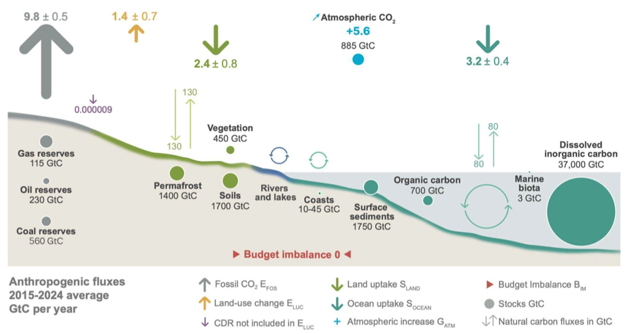

<sub>https://doi.org/10.5194/essd-2025-659</sub>

## Role of vegetation in global carbon budget

- 9.8 Gt/yr emissions to atmospheric CO<sub>2</sub>
- Atmospheric CO<sub>2</sub> only goes up by 5.6 (Gt/yr) = 57% (half the warming!)
- 25% of emissions are absorbed by terrestrial ecosystems

## Vegetation carbon is important

- Increasing carbon on land (e.g., forests) decreases carbon in the atmosphere
- Decreasing carbon in the atmosphere, decreasing global temperatures (or prevents more warming)
- Can we manage the land to increase the amount of carbon in ecosystems?
- Basis for carbon markets - you pay for my extra ecosystem carbon to offset your fossil fuel emissions)

## Measuring Carbon: NEON

[video not shown]

## NEON: 81 sites

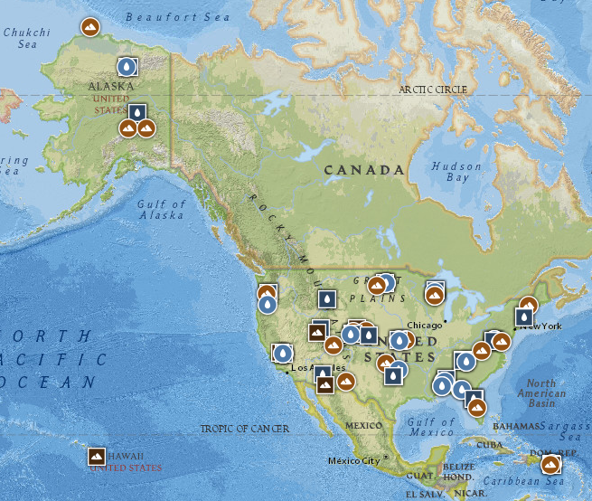

https://www.neonscience.org/field-sites/explore-field-sites

## NEON Woody Carbon

- Each site has a set of plots (either “tower” or “distributed”)
- Each tree is mapped (species)
- Each year, each tree is measured: status (live or dead) and diameter

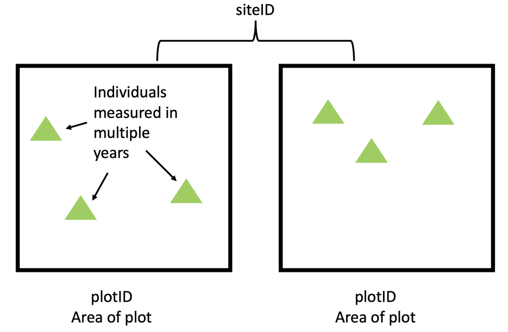

## NEON Woody Carbon

- Diameter can be converted to biomass using “allometric” relationships
- Biomass can be converted to carbon (carbon = biomass x 0.5)
- Allometric relationships are from Jenkin et al. (2004)

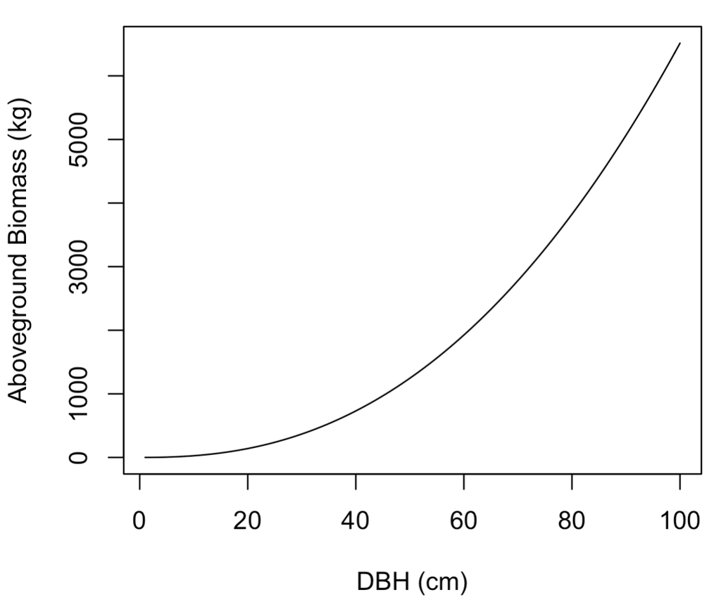

## NEON Woody Carbon

- Carbon for individual trees is summed within a plot to determine the plot carbon each year
- The summed carbon is divided by the area (m^2) of the plot to standardize across plots of different size
- All plots within a site averaged to get a site-level carbon for each year.

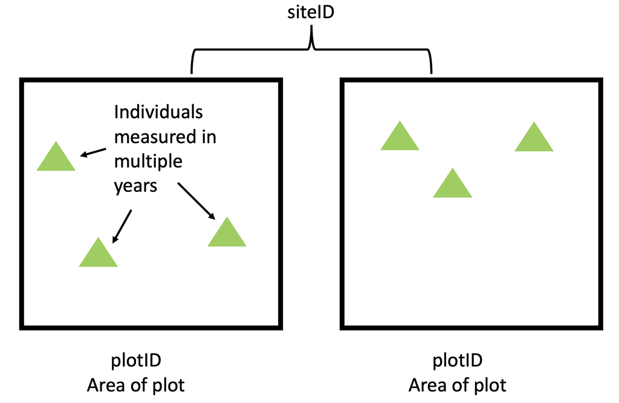

## Structure of data

- Data is spread across multiple tables
- The data are stored in a relational database.

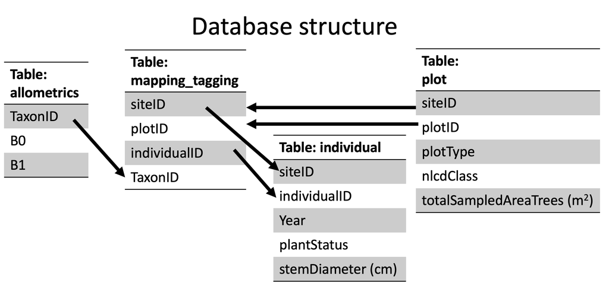

## New skills

- Reading in database in R (`collect`)
- Joining tables to create data frames for analysis (`left_join`)
- Filtering on strings (`str_detect`)

## Science Question

- How much carbon is stored in a forest ecosystem and how does it differ across the U.S.?
- I am a “client” interested in the carbon storage in vegetation of different ecosystems across the continental U.S. to guide my investment in the California Carbon Market.
- Specifically, I want carbon stocks estimates from four sites in NEON

## Structure of module

- Today, you will make a hypothesis about patterns in carbon and submit to Canvas (Assignment 6.1)
- Thursday: Training in databases
- Tuesday: In-class database problem
- Thursday: Quiz and introduction to the cloud

## What is a database?

- A structured, persistence storage of data
- Relational (strict standards) vs Non-relational (more flexible)
- We focus on relational databases here

## Database vs. CSV

- A CSV is like a dataframe (table) where all columns need to have same number of rows
- Databases can have multiple tables
- Tables can have different numbers of rows
- Database has data storage and access efficiency

## What is a relationship database?

- Data in tables with rows and columns
- Tables connect to one another through keys
  - Primary (ids within a table) - one per table
  - Foreign (reference ids in another table) - can have multiple per table

## You have the skills to work with databases!

- Filter, Select, Group By, Summarize
- Develop skills in joins within this module

## SQL is the databse language

- SQL (Structured Query Language)
- Tidyverse helps translate functions in SQL language
- We focus on tidyverse approach but know that SQL is under the hood

```
species <- tbl(con, "species") |>
  filter(genus == "Calamospiza") |>
  select(taxa)
```

is actually

```
"SELECT taxa FROM species WHERE genus == 'Calamospiza'"
```

in SQL

## “Brand” of database

- Common types of relationship databases are PostgreSQL, MySQL, SQLite, duckDB
- We use duckDB in this class
- Concepts and code access are largely the same with details different

## Accessing database

First connect to database

```
library(DBI)
con <- dbConnect(duckdb::duckdb(), "rat_data.db")
```

extract data

```
species <- tbl(con, "species") |>
  filter(genus == "Calamospiza") |>
  select(taxa) |>
  collect()
```

close database

```
dbDisconnect(con)
```

## Building databases

- Create database (or open existing)
- Add tables
- Be sure that tables have keys that connect them!
- Be sure to append when adding data to existing database

## Keys are critical for joining tables with a database

- Joins are used to combine tables
- Pulling data from one table into another
- Using one table to filter another table

## Mutating joins

- Never lose information from the left (or right) table so fills with NA
- Mutate join because add columns
- `left_join`: Keep all rows in the left side table (e.g., `df1` in `left_join(df1, df2)`)
- `right_join`: Keep all rows in the right side table (e.g., `df2` in `right_join(df1, df2)`)
- `inner_join`: Keep all rows in both tables
- `full_join`: Keep all rows in either table

## Filtering joins

- Use information in one table to reduce the number of rows in another table
- Does not add columns to the left side.
- `semi_join`: keep rows in left side table with match in right table
- `anti_join`: keeps rows in left side table without match in right table

## Defining keys

- tidyverse will try to detect the keys by looking at columns with the same names
- Better to specify the keys used to join tables
- While `left_join(df1, df2)` works, `left_join(df1, df2, by = c("site_id")` is better
- `by` allows you to join using columns with different names: `left_join(df1, df2, by = c("site_id" = "siteID")`